# QC report

- study: Illumina methylation data
- author: Analyst
- date: 25 November, 2016

## Parameters used for QC

```
## $colour.code
## NULL
##
## $control.categories
## NULL
##
## $sex.outlier.sd
## [1] 5
##
## $meth.unmeth.outlier.sd
## [1] 3
##
## $control.means.outlier.sd
## [1] 5
##
## $detectionp.samples.threshold
## [1] 0.1
##
## $beadnum.samples.threshold
## [1] 0.1
##
## $detectionp.cpgs.threshold
## [1] 0.1
##
## $beadnum.cpgs.threshold
## [1] 0.1
##
## $snp.concordance.threshold
## [1] 0.95
##
## $sample.genotype.concordance.threshold
## [1] 0.8
##
## $detection.threshold
## [1] 0.01
##
## $bead.threshold
## [1] 3
##
## $sex.cutoff
## [1] -2
```

## Sex mismatches

| sample.name | predicted.sex | declared.sex | xy.diff | status |
| --- | --- | --- | --- | --- |
| 13619 | M | F | -1.1040461 | mismatched |
| 13026 | F | F | -3.1879477 | outlier |
| 10668 | F | F | -3.0641925 | outlier |
| 10675 | F | F | -3.0604413 | outlier |
| 13107 | F | F | -2.0645331 | outlier |
| 12779 | F | F | -2.0413694 | outlier |
| 13626 | M | M | -1.1090342 | outlier |
| 12605 | M | M | -1.0932113 | outlier |
| 521450 | M | M | -1.0854298 | outlier |
| 13812 | M | M | -0.9987728 | outlier |
| 14019 | M | M | -0.8497822 | outlier |
| 13735 | M | M | -0.8425437 | outlier |
| 10141 | M | M | -0.7759218 | outlier |
| 12910 | M | M | -0.7612204 | outlier |
| 007JRT-C | M | M | -0.7348982 | outlier |

This is a plot of the difference between median chromosome Y and chromosome X probe intensities (“XY diff”). Cutoff for sex detection was XY diff = -2.

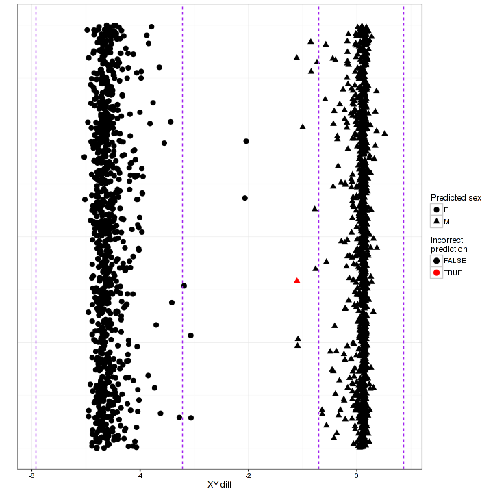

## Methylated vs unmethylated

There are 14 outliers from the meth vs unmeth comparison. Outliers are samples whose predicted median methylated signal is more than 3 standard deviations from the expected (regression line).

| sample.name | methylated | unmethylated | resids | methylated.lm | upper.lm | lower.lm | outliers |
| --- | --- | --- | --- | --- | --- | --- | --- |
| 10698 | 2600.133 | 2497.286 | -889.8984 | 3490.032 | 4208.121 | 2771.942 | TRUE |
| 12381 | 2460.033 | 2139.633 | -936.0161 | 3396.049 | 4114.139 | 2677.959 | TRUE |
| 12762 | 2972.715 | 3891.438 | -883.6662 | 3856.381 | 4574.471 | 3138.291 | TRUE |
| 13287 | 2831.541 | 2810.391 | -740.7667 | 3572.308 | 4290.398 | 2854.218 | TRUE |
| 13792 | 3322.428 | 5074.339 | -844.7906 | 4167.219 | 4885.309 | 3449.129 | TRUE |
| 10364 | 2754.361 | 2671.923 | -781.5612 | 3535.922 | 4254.012 | 2817.832 | TRUE |
| 13683 | 2610.922 | 2781.089 | -953.6864 | 3564.608 | 4282.698 | 2846.519 | TRUE |
| 13628 | 3319.044 | 5036.707 | -838.2858 | 4157.330 | 4875.420 | 3439.240 | TRUE |
| 13756 | 3247.109 | 4365.554 | -733.8587 | 3980.967 | 4699.057 | 3262.878 | TRUE |
| 12910 | 2931.397 | 3228.001 | -750.6492 | 3682.046 | 4400.136 | 2963.956 | TRUE |
| 14019 | 2542.591 | 1915.050 | -794.4431 | 3337.034 | 4055.124 | 2618.944 | TRUE |
| 12418 | 2945.750 | 3288.874 | -752.2920 | 3698.042 | 4416.132 | 2979.952 | TRUE |
| 13655 | 2879.592 | 2970.944 | -734.9054 | 3614.498 | 4332.587 | 2896.408 | TRUE |
| 13654 | 2830.799 | 3141.571 | -828.5356 | 3659.334 | 4377.424 | 2941.245 | TRUE |

This is a plot of the methylation signals vs unmethylated signals

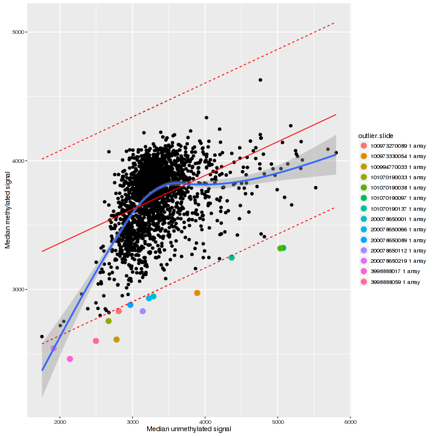

## Control probe means

There were 23 outliers detected based on deviations from mean values for control probes.

| sample.name | colour.code | id | variable | value | outliers |
| --- | --- | --- | --- | --- | --- |
| 12423 | 1 | 433 | stain.G | 6.227800e+04 | TRUE |
| 12958 | 1 | 938 | stain.G | 5.614000e+04 | TRUE |
| 10698 | 1 | 171 | spec1.R.46779338 | 1.462000e+03 | TRUE |
| 13600 | 1 | 1301 | spec2.G.29662396 | 1.305000e+03 | TRUE |
| 12478 | 1 | 399 | spec2.G.34730329 | 8.210000e+02 | TRUE |
| 12887 | 1 | 614 | spec2.G.34730329 | 1.096000e+03 | TRUE |
| 14395 | 1 | 921 | spec2.G.34730329 | 9.570000e+02 | TRUE |
| 10698 | 1 | 171 | spec2.R.29662396 | 1.389000e+03 | TRUE |
| 13249 | 1 | 939 | spec1.ratio1 | 1.059123e-01 | TRUE |
| 13026 | 1 | 1352 | spec1.ratio1 | 9.752720e-02 | TRUE |
| 10668 | 1 | 1859 | spec1.ratio1 | 8.470380e-02 | TRUE |
| 10698 | 1 | 171 | spec1.ratio | 9.434860e-02 | TRUE |
| 13753 | 1 | 180 | spec1.ratio | 6.972170e-02 | TRUE |
| 13249 | 1 | 939 | spec1.ratio | 7.518890e-02 | TRUE |
| 13026 | 1 | 1352 | spec1.ratio | 7.869570e-02 | TRUE |
| 10668 | 1 | 1859 | spec1.ratio | 9.365210e-02 | TRUE |
| 10698 | 1 | 171 | spec2.ratio | 1.418569e-01 | TRUE |
| 10668 | 1 | 1859 | spec2.ratio | 9.363370e-02 | TRUE |
| 10698 | 1 | 171 | spec1.ratio2 | 1.061468e-01 | TRUE |
| 13687 | 1 | 179 | spec1.ratio2 | 8.594750e-02 | TRUE |
| 13753 | 1 | 180 | spec1.ratio2 | 9.057720e-02 | TRUE |
| 10668 | 1 | 1859 | spec1.ratio2 | 1.026005e-01 | TRUE |
| 12887 | 1 | 614 | oob.G.99% | 5.935540e+03 | TRUE |

The distribution of sample control means are plotted here:

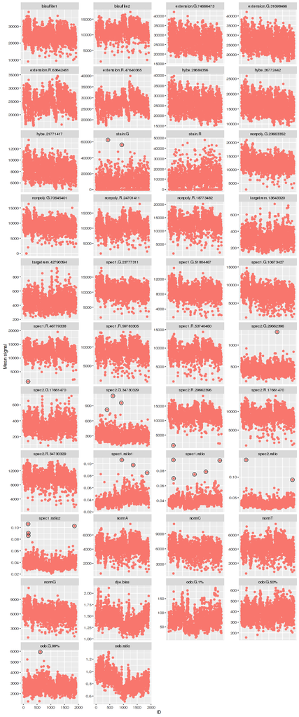

## Sample detection p-values

There were 0 samples with a high proportion of undetected probes (proportion of probes with detection p-value > 0.01 is > 0.1).

Distribution:

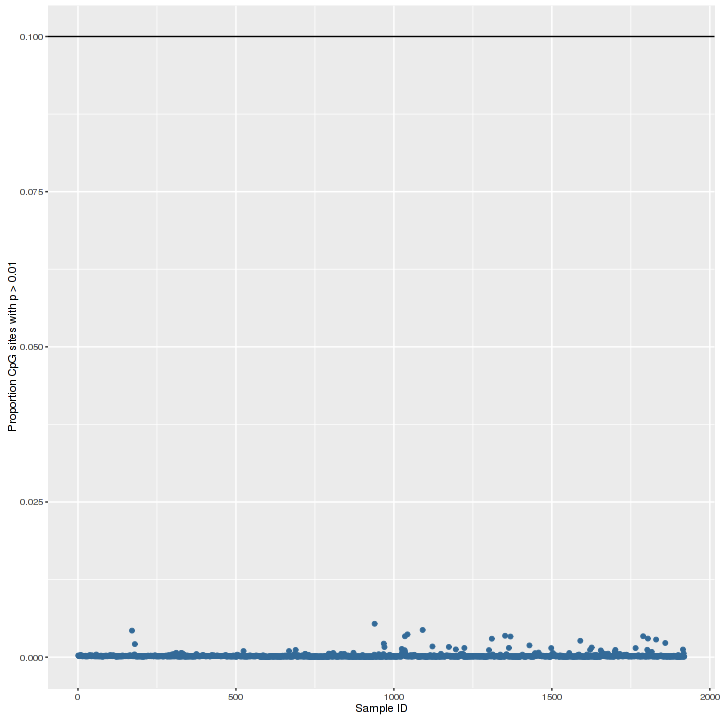

## Sample bead numbers

There were 0 samples with a high proportion of probes with low bead number (proportion of probes with bead number < 3 is > 0.1).

Distribution:

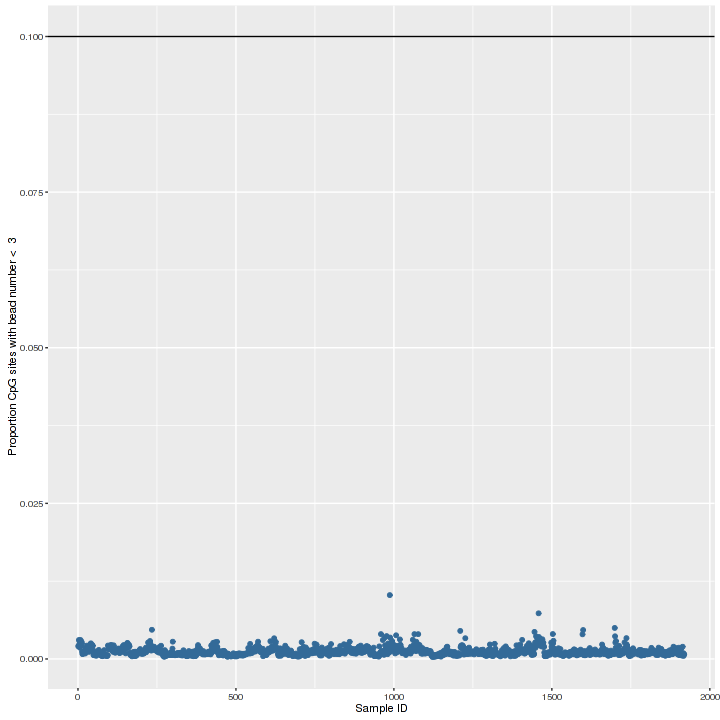

## CpG detection p-values

There were 165 probes with only background signal in a high proportion of samples (proportion of samples with detection p-value > 0.01 is > 0.1). Manhattan plot shows the proportion of samples.

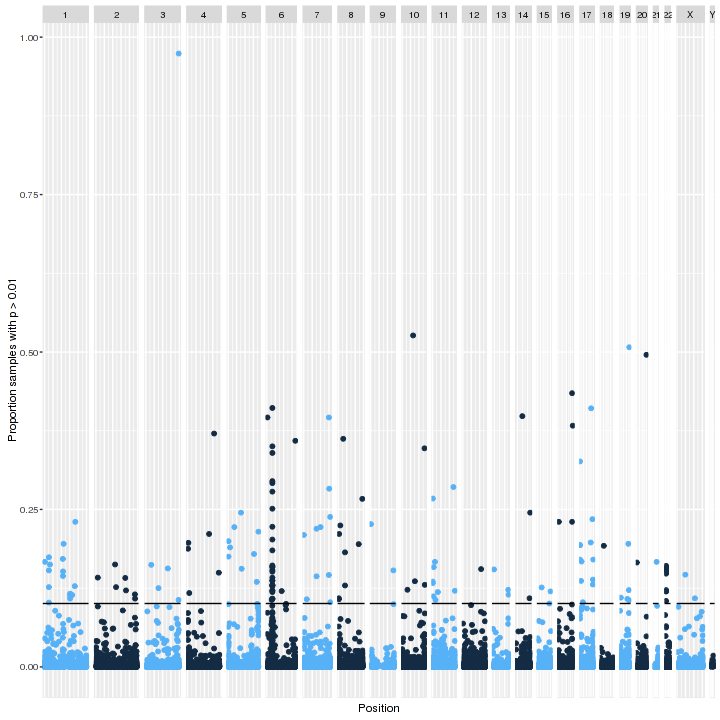

## Low number of beads per CpG

There were 118 CpGs with low bead numbers in a high proportion of samples (proportion of samples with bead number < 3 is > 0.1). Manhattan plot of proportion of samples.

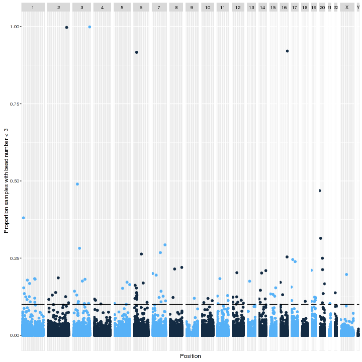

## Cell count estimates

Cell counts were estimated using the blood gse35069 complete cell type methylation profile references.

Plot compares methylation levels of CpG sites used to estimate cell counts for each sample and reference methylation profile. Methylation levels of samples should generally overlap with reference methylation levels otherwise estimation will have simply selected the cell type reference with the nearest mean methylation level.

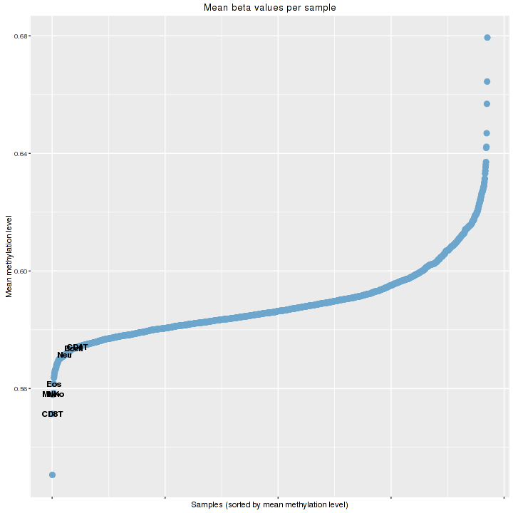

Boxplot shows the distributions of estimated cell counts for each reference cell type across all samples.

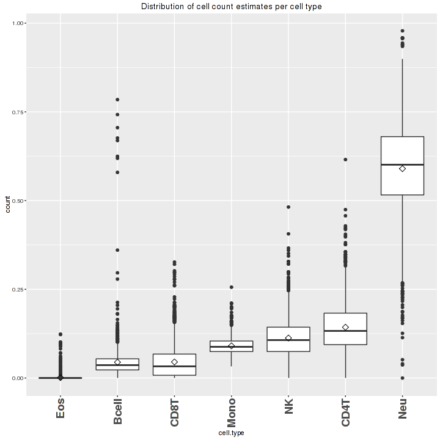

## SNP probe beta values

Distributions of SNP probe beta values.

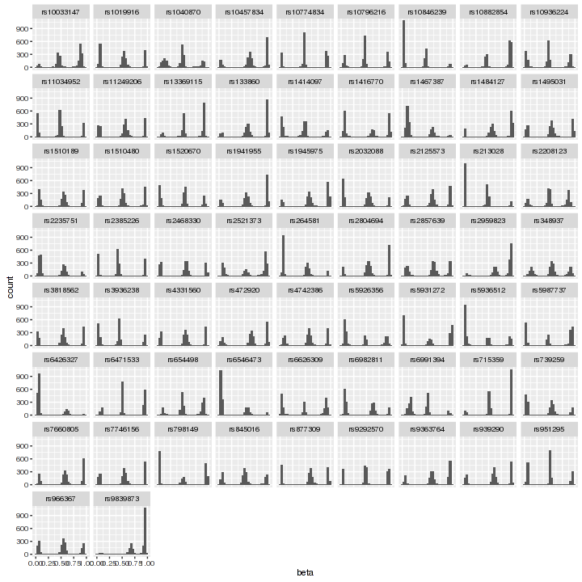

## Genotype concordance

This section omitted.